# Baltimore Crime Analysis

# Goal

To create a heatmap of Baltimore city crime data, in an effort to determine where *NOT* to live.

# Approach

I plan to create a google fusion table because it has heatmap functionality built in and I might be able to easily overlay it on the housing map I already have (which really would speed things up).

Here my goal is to prep data for fusion table. It needs geocodes for approximate location (which it already has) and I want to take advantage of the optional weights to better represent the dangers as I personally perceive them.

# Import data

```r
dl_date <- Sys.Date()

save_file <- gsub("-", "", dl_date) %>%
    paste0("~/Housing/", ., "-BPD_Part1_crime.csv")
BC_crime_url <- "https://data.baltimorecity.gov/api/views/wsfq-mvij/rows.csv?accessType=DOWNLOAD"
```

```r
download.file(BC_crime_url, destfile = save_file)
```

```r
crime <- read_csv(save_file, col_types =
                      cols(
                          CrimeDate = col_date(format = "%m/%d/%Y"),
                          CrimeTime = col_character(), #problems with time format
                          CrimeCode = col_factor(levels = NULL),
                          Location = col_character(),
                          Description = col_factor(levels = NULL),
                          `Inside/Outside` = col_factor(levels = NULL),
                          Weapon = col_factor(levels = NULL),
                          Post = col_integer(),
                          District = col_character(),
                          Neighborhood = col_character(),
                          Longitude = col_double(),
                          Latitude = col_double(),
                          `Location 1` = col_character(),
                          Premise = col_character(),
                          `Total Incidents` = col_integer()
                          )
                  )
problems(crime)
```

| row | col | expected | actual |
| --- | --- | --- | --- |

## TIME adjustment

Just realized that time doens’t really matter for my purposes. I’m just interested in date.

```r
time_err_ind <- !grepl(":", crime$CrimeTime)
sum(time_err_ind) # number of errors
```

```
[1] 4324
```

```r
time_err <- crime$CrimeTime[time_err_ind]
```

examine time errors

```r
head(time_err, 50)
```

```
 [1] "1218" "2014" "1929" "1859" "1859" "1840" "0245" "1856" "1834" "1834" "0257"
[12] "1658" "1658" "1658" "1545" "1620" "2100" "2010" "1956" "1326" "2013" "1710"
[23] "1710" "1710" "1706" "1050" "2324" "2208" "1857" "2118" "1316" "2115" "1835"
[34] "1200" "1123" "2126" "1902" "1457" "1312" "1226" "2228" "1601" "2208" "0322"
[45] "0322" "0322" "0211" "0055" "1639" "1639"
```

```r
# string length of errors
str_len <- nchar(time_err)
table(str_len)
```

```
str_len
   3    4    5
   1 4322    1
```

```r
time_err[str_len != 4]
```

```
[1] "1826h" "242"
```

don’t strip seconds, there are unique values

```r
# any seconds besides '00' in correctly formatted values
sub("(.*)(\\:[0-9]{2}$)", "\\2", crime$CrimeTime) %>%
    unique() %>%
    head(50)
```

```
 [1] ":00"  "1218" "2014" "1929" "1859" "1840" "0245" "1856" "1834" ":13"  "0257"
[12] "1658" "1545" "1620" ":09"  ":10"  "2100" "2010" "1956" ":33"  "1326" ":50"
[23] "2013" "1710" "1706" ":43"  ":11"  "1050" ":49"  "2324" ":22"  ":03"  ":56"
[34] ":38"  "2208" "1857" ":32"  ":46"  "2118" ":07"  "1316" ":19"  ":54"  "2115"
[45] "1835" "1200" ":31"  "1123" "2126" "1902"
```

Stripped “h” from 5 length error, added “0” to front of 3 length error and then added “:” to the middle of every time plus “:00:” at end to make time format all the same.

```r
time_adj <- crime$CrimeTime
time_adj <- gsub("h", "", time_adj)
unique(nchar(time_adj))
```

```
[1] 8 4 5 3
```

still has length 5 character?

```r
time_adj[nchar(time_adj) == 5]
```

```
[1] "12:27"
```

it has a colon so it’s fine. I’ll just process all the 4 lengths in 2 steps to capture it

fix 3 length issue

```r
time_adj <- if_else(nchar(time_adj) == 3, paste0("0", time_adj), time_adj)
unique(nchar(time_adj))
```

```
[1] 8 4 5
```

adj all

```r
time_adj <- if_else(nchar(time_adj) == 4,
               sub("([0-9]{2})([0-9]{2})", "\\1:\\2", time_adj),
               time_adj)
unique(nchar(time_adj))
```

```
[1] 8 5
```

```r
time_adj[nchar(time_adj) == 5] %>% head(50) #looks good, add secs
```

```
 [1] "12:18" "20:14" "19:29" "18:59" "18:59" "18:40" "02:45" "18:56" "18:34" "18:34"
[11] "02:57" "16:58" "16:58" "16:58" "15:45" "16:20" "21:00" "20:10" "19:56" "13:26"
[21] "20:13" "17:10" "17:10" "17:10" "17:06" "10:50" "23:24" "22:08" "18:57" "21:18"
[31] "13:16" "21:15" "18:35" "12:00" "11:23" "21:26" "19:02" "14:57" "13:12" "12:26"
[41] "22:28" "16:01" "22:08" "03:22" "03:22" "03:22" "02:11" "00:55" "16:39" "16:39"
```

```r
time_adj <- if_else(nchar(time_adj) == 5,
               paste0(time_adj, ":00"),
               time_adj)
unique(nchar(time_adj))
```

```
[1] 8
```

```r
# reformat as date
crime <- mutate(crime, CrimeTime = parse_time(time_adj, format = "%H:%M:%S"))
head(crime$CrimeTime, 20)
```

```
23:55:00
23:37:00
23:00:00
22:25:00
21:56:00
21:50:00
21:30:00
21:15:00
21:03:00
21:00:00
21:00:00
20:36:00
20:30:00
20:24:00
20:15:00
20:00:00
19:14:00
19:00:00
18:51:00
18:50:00
```

```r
unique(nchar(crime$CrimeTime))
```

```
[1] 5 4 1 3 2
```

# Generate weights

what data is available?

```r
str(crime)
```

```
Classes tbl_df, tbl and 'data.frame':   251676 obs. of  15 variables:
 $ CrimeDate      : Date, format: "2018-03-03" "2018-03-03" ...
 $ CrimeTime      :Classes 'hms', 'difftime'  atomic [1:251676] 86100 85020 82800 80700 78960 ...
  .. ..- attr(*, "units")= chr "secs"
 $ CrimeCode      : Factor w/ 81 levels "6J","4C","4E",..: 1 2 3 3 3 2 4 3 5 6 ...
 $ Location       : chr  "1000 ASHLAND CT" "2800 W NORTH AVE" "1400 E FORT AVE" "800 E JEFFREY ST" ...
 $ Description    : Factor w/ 15 levels "LARCENY","AGG. ASSAULT",..: 1 2 3 3 3 2 4 3 5 2 ...
 $ Inside/Outside : Factor w/ 4 levels "I","O","Outside",..: 1 1 1 1 1 1 1 1 1 1 ...
 $ Weapon         : Factor w/ 4 levels "OTHER","HANDS",..: NA 1 2 2 2 1 NA 2 3 2 ...
 $ Post           : int  312 811 943 913 111 415 323 841 721 426 ...
 $ District       : chr  "EASTERN" "SOUTHWESTERN" "SOUTHERN" "SOUTHERN" ...
 $ Neighborhood   : chr  "Oldtown" "Walbrook" "Locust Point" "Brooklyn" ...
 $ Longitude      : num  -76.6 -76.7 -76.6 -76.6 -76.6 ...
 $ Latitude       : num  39.3 39.3 39.3 39.2 39.3 ...
 $ Location 1     : chr  "(39.30019, -76.60352)" "(39.30923, -76.66498)" "(39.26944, -76.59492)" "(39.23236, -76.60041)" ...
 $ Premise        : chr  "ROW/TOWNHO" "ROW/TOWNHO" "BARBER/BEA" "ROW/TOWNHO" ...
 $ Total Incidents: int  1 1 1 1 1 1 1 1 1 1 ...
```

i don’t know what the crime code means and a quick [google search](https://www.google.com/search?q=baltimore+city+crime+code&rlz=1C1CHBF_enUS752US752&oq=baltimore+city+crime+code&aqs=chrome..69i57j69i65j0j69i64.3269j0j7&sourceid=chrome&ie=UTF-8) didn’t help me figure it out so I’ll just leave it alone.

The helpful variables will be the ‘Description’ and ‘Weapon’. I don’t know if it being inside or outside would be worse and if it happened in a house or business doesn’t matter so much to me because the proximity to danger is the same, so `Premise` doesn’t matter. I wonder if there are any `Total Incidents` greater than 1. That might matter

```r
sum(crime$`Total Incidents` > 1)
```

```
[1] 0
```

```r
sum(crime$`Total Incidents` != 1)
```

```
[1] 0
```

‘Total Incidents’ is always 1 so that’s useless.

So, I’ll want my final weight to be some combination of `Description` and `Weapon` adjusted for time (because it’s less relevant if it happened years ago).

## Determine Description + Weapon weights

The more dangerous something is to my family the worse it is. So, I’ll weight those higher. I also want to protect my car if possible, preferentially from being stolen completely and then from damage. I’m less worried about stuff being stolen from it because I can leave it somewhat empty (minus the emergency stuff).

```r
levels(crime$Description) %>% sort()
```

```
 [1] "AGG. ASSAULT"         "ARSON"                "ASSAULT BY THREAT"
 [4] "AUTO THEFT"           "BURGLARY"             "COMMON ASSAULT"
 [7] "HOMICIDE"             "LARCENY"              "LARCENY FROM AUTO"
[10] "RAPE"                 "ROBBERY - CARJACKING" "ROBBERY - COMMERCIAL"
[13] "ROBBERY - RESIDENCE"  "ROBBERY - STREET"     "SHOOTING"
```

```r
count(crime, Description) %>% arrange(desc(n))
```

| Description | n |
| --- | --- |
| LARCENY | 54692 |
| COMMON ASSAULT | 40200 |
| BURGLARY | 38511 |
| LARCENY FROM AUTO | 32015 |
| AUTO THEFT | 25435 |
| AGG. ASSAULT | 25236 |
| ROBBERY - STREET | 16933 |
| ROBBERY - COMMERCIAL | 4132 |
| ASSAULT BY THREAT | 3134 |
| SHOOTING | 2835 |

[output cut: 5 more lines]

```r
levels(crime$Weapon)
```

```
[1] "OTHER"   "HANDS"   "FIREARM" "KNIFE"
```

I’m not sure what ‘OTHER’ weapon refers to.

```r
count(crime, Description, Weapon) %>%
    spread(key = Weapon, value = n) %>%
    arrange(desc(FIREARM), desc(KNIFE), desc(OTHER))
```

| Description | OTHER | HANDS | FIREARM | KNIFE | <NA> |
| --- | --- | --- | --- | --- | --- |
| ROBBERY - STREET | 1188 | NA | 7863 | 1679 | 6203 |
| AGG. ASSAULT | 10354 | 3105 | 5619 | 6158 | NA |
| SHOOTING | NA | NA | 2835 | NA | NA |
| ROBBERY - COMMERCIAL | 316 | NA | 2406 | 409 | 1001 |
| HOMICIDE | 99 | NA | 1256 | 135 | NA |
| ROBBERY - CARJACKING | 86 | NA | 1136 | 83 | 320 |
| ROBBERY - RESIDENCE | 171 | NA | 836 | 190 | 1390 |
| RAPE | 1371 | NA | NA | NA | 155 |
| LARCENY | NA | NA | NA | NA | 54692 |
| COMMON ASSAULT | NA | 40200 | NA | NA | NA |

[output cut: 5 more lines]

Based on comparison to firearms and knives it looks like ‘Other’ is weapons worse than ‘Hands’, so I’ll weight them in that order.

If I were to order the type of crime alone it would probably be:

1. HOMICIDE
2. **AGG. ASSAULT** = serious bodily harm, probably includes rape with firearm/knife
3. RAPE
4. SHOOTING
5. ROBBERY - RESIDENCE
   - **ROBBERY** = use of force
6. ROBBERY - CARJACKING
7. ROBBERY - STREET
8. **AUTO THEFT** = stolen car (w/o force)
9. COMMON ASSAULT
10. ROBBERY - COMMERCIAL
11. **BURGLARY** = entering a place illegally w/some illegal intent
12. **ASSAULT BY THREAT** = likely only words, never occurs with weapon
13. ARSON
14. LARCENY FROM AUTO
    - **LARCENY** = theft without use of force
15. LARCENY

Larceny comes with living in a city. We’ll deal with it.

There’s going to be some relatedness between type of weapon and crime. I’ll quickly replace any `NA` values with the value `None` and then examine the relatedness of weapon and description using a decision tree and some correlation calcs before I decide on final weights and how to organize them.

```r
sum(is.na(crime$Description))
```

```
[1] 0
```

```r
sum(is.na(crime$Weapon))
```

[output not shown]

```r
crime <- mutate(crime,
                Weapon = as.factor(
                    if_else(is.na(Weapon), "NONE", as.character(Weapon))
                    )
)
str(crime)
```

```
Classes tbl_df, tbl and 'data.frame':   251676 obs. of  15 variables:
 $ CrimeDate      : Date, format: "2018-03-03" "2018-03-03" ...
 $ CrimeTime      :Classes 'hms', 'difftime'  atomic [1:251676] 86100 85020 82800 80700 78960 ...
  .. ..- attr(*, "units")= chr "secs"
 $ CrimeCode      : Factor w/ 81 levels "6J","4C","4E",..: 1 2 3 3 3 2 4 3 5 6 ...
 $ Location       : chr  "1000 ASHLAND CT" "2800 W NORTH AVE" "1400 E FORT AVE" "800 E JEFFREY ST" ...
 $ Description    : Factor w/ 15 levels "LARCENY","AGG. ASSAULT",..: 1 2 3 3 3 2 4 3 5 2 ...
 $ Inside/Outside : Factor w/ 4 levels "I","O","Outside",..: 1 1 1 1 1 1 1 1 1 1 ...
 $ Weapon         : Factor w/ 5 levels "FIREARM","HANDS",..: 4 5 2 2 2 5 4 2 1 2 ...
 $ Post           : int  312 811 943 913 111 415 323 841 721 426 ...
 $ District       : chr  "EASTERN" "SOUTHWESTERN" "SOUTHERN" "SOUTHERN" ...
 $ Neighborhood   : chr  "Oldtown" "Walbrook" "Locust Point" "Brooklyn" ...
 $ Longitude      : num  -76.6 -76.7 -76.6 -76.6 -76.6 ...
 $ Latitude       : num  39.3 39.3 39.3 39.2 39.3 ...
 $ Location 1     : chr  "(39.30019, -76.60352)" "(39.30923, -76.66498)" "(39.26944, -76.59492)" "(39.23236, -76.60041)" ...
 $ Premise        : chr  "ROW/TOWNHO" "ROW/TOWNHO" "BARBER/BEA" "ROW/TOWNHO" ...
 $ Total Incidents: int  1 1 1 1 1 1 1 1 1 1 ...
```

### Description ~ Weapon

```r
# Weapon ~ Description was not what I wanted
crime_tree <- train(Description ~ Weapon, data = crime, method = "rpart")
crime_tree
```

```
CART

251676 samples
     1 predictor
    15 classes: 'LARCENY', 'AGG. ASSAULT', 'COMMON ASSAULT', 'ROBBERY - RESIDENCE', 'ROBBERY - COMMERCIAL', 'ROBBERY - STREET', 'LARCENY FROM AUTO', 'BURGLARY', 'AUTO THEFT', 'ROBBERY - CARJACKING', 'ASSAULT BY THREAT', 'ARSON', 'SHOOTING', 'HOMICIDE', 'RAPE'

No pre-processing
Resampling: Bootstrapped (25 reps)
Summary of sample sizes: 251676, 251676, 251676, 251676, 251676, 251676, ...
Resampling results across tuning parameters:

  cp           Accuracy   Kappa
  0.005695894  0.4695988  0.34881156
  0.112349226  0.4262706  0.28559414
  0.204077489  0.2875346  0.09382636

Accuracy was used to select the optimal model using the largest value.
The final value used for the model was cp = 0.005695894.
```

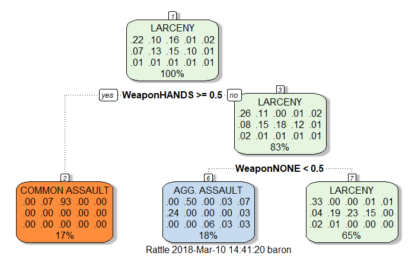

```r
fancyRpartPlot(crime_tree$finalModel)
```

Shows predicted class, predicted probability of each class, and percentage of observations in each node (but I don’t know the order). Oh well, that turned out to be less useful than I thought since the model only took into account hands and none as weapons.

Let’s calculate the [strength of association](https://stats.stackexchange.com/questions/108007/correlations-with-unordered-categorical-variables) using [Cramér’s V](https://en.wikipedia.org/wiki/Cram%C3%A9r%27s_V) and the [vcd](https://www.rdocumentation.org/packages/vcd/versions/1.4-4/topics/assocstats) package.

```r
assocstats(table(crime$Description, crime$Weapon))
```

```
                    X^2 df P(> X^2)
Likelihood Ratio 413153 56        0
Pearson          510717 56        0

Phi-Coefficient   : NA
Contingency Coeff.: 0.818
Cramer's V        : 0.712
```

```r
chisq.test(crime$Description, crime$Weapon)
```

```
    Pearson's Chi-squared test

data:  crime$Description and crime$Weapon
X-squared = 510720, df = 56, p-value < 2.2e-16
```

### Final `Description` and `Weapon` weights

For `Description` I will weight things as follows:

- 1 = rank 15 to 12 (LARCENY, LARCENY FROM AUTO, ARSON, ASSAULT BY THREAT)
- 2 = rank 11 and 10 (BURGLARY, ROBBERY - COMMERCIAL)
- 4.5 = rank 9 to 7 (COMMON ASSAULT, AUTO THEFT, ROBBERY - STREET)
- 6 = rank 6 and 5 (ROBBERY - CARJACKING, ROBBERY - RESIDENCE)
- 7 = rank 4 to 1 (SHOOTING, RAPE, AGG. ASSAULT, HOMICIDE)

For `Weapon` I will weight things as follows:

- 0 = NONE or HANDS
- 3 = OTHER
- 5 = KNIFE
- 7 = FIREARM

These 2 weights will be added to create a final Crime-Weapon weight and adjusted so that the lowest value is 1 (*i.e.* has no special weight).

```r
crime_wt <- c(LARCENY = 1, 'LARCENY FROM AUTO' = 1, ARSON = 1,
              'ASSAULT BY THREAT' = 1, BURGLARY = 2, 'ROBBERY - COMMERCIAL' = 2,
              'COMMON ASSAULT' = 4.5, 'AUTO THEFT' = 4.5, 'ROBBERY - STREET' = 4.5,
              'ROBBERY - CARJACKING' = 6, 'ROBBERY - RESIDENCE' = 6, SHOOTING = 7,
              RAPE = 7, 'AGG. ASSAULT' = 7, HOMICIDE = 7)
crime_wt <- as.data.frame(crime_wt) %>%
    rownames_to_column(var = "Description")
wep_wt <- c(NONE = 0, HANDS = 0, OTHER = 3, KNIFE = 5, FIREARM = 7)
wep_wt <- as.data.frame(wep_wt) %>%
    rownames_to_column(var = "Weapon")
crime <- left_join(crime, crime_wt, by = "Description") %>%
    left_join(wep_wt, by = "Weapon")
str(crime)
```

```
Classes tbl_df, tbl and 'data.frame':   251676 obs. of  17 variables:
 $ CrimeDate      : Date, format: "2018-03-03" "2018-03-03" ...
 $ CrimeTime      :Classes 'hms', 'difftime'  atomic [1:251676] 86100 85020 82800 80700 78960 ...
  .. ..- attr(*, "units")= chr "secs"
 $ CrimeCode      : Factor w/ 81 levels "6J","4C","4E",..: 1 2 3 3 3 2 4 3 5 6 ...
 $ Location       : chr  "1000 ASHLAND CT" "2800 W NORTH AVE" "1400 E FORT AVE" "800 E JEFFREY ST" ...
 $ Description    : chr  "LARCENY" "AGG. ASSAULT" "COMMON ASSAULT" "COMMON ASSAULT" ...
 $ Inside/Outside : Factor w/ 4 levels "I","O","Outside",..: 1 1 1 1 1 1 1 1 1 1 ...
 $ Weapon         : chr  "NONE" "OTHER" "HANDS" "HANDS" ...
 $ Post           : int  312 811 943 913 111 415 323 841 721 426 ...
 $ District       : chr  "EASTERN" "SOUTHWESTERN" "SOUTHERN" "SOUTHERN" ...
 $ Neighborhood   : chr  "Oldtown" "Walbrook" "Locust Point" "Brooklyn" ...
 $ Longitude      : num  -76.6 -76.7 -76.6 -76.6 -76.6 ...
 $ Latitude       : num  39.3 39.3 39.3 39.2 39.3 ...
 $ Location 1     : chr  "(39.30019, -76.60352)" "(39.30923, -76.66498)" "(39.26944, -76.59492)" "(39.23236, -76.60041)" ...
 $ Premise        : chr  "ROW/TOWNHO" "ROW/TOWNHO" "BARBER/BEA" "ROW/TOWNHO" ...
 $ Total Incidents: int  1 1 1 1 1 1 1 1 1 1 ...
 $ crime_wt       : num  1 7 4.5 4.5 4.5 7 6 4.5 2 7 ...
 $ wep_wt         : num  0 3 0 0 0 3 0 0 7 0 ...
```

## Weight adjusted by time

Events that happened years ago should be weighted less. I need to determine how many events happen in a year to have some idea as to how to weight them.

```r
tmp <- tibble(year = year(crime$CrimeDate), month = month(crime$CrimeDate))
# crimes/year
table(tmp$year)
```

```
 2013  2014  2015  2016  2017  2018
49568 45973 48858 48847 51753  6677
```

```r
# mean(crimes)/month
table(tmp$year, tmp$month) %>%
    .[. > 500] %>%  # removes current and future months (with low counts)
    mean()
```

```
[1] 4055.839
```

That’s a lot of crime in a month and year. Let’s see, I guess the best way to do it is to select a period that will not be down-weighted and then gradually down-weight by month (I may have to iterate on this). In the last size months there would have been about 2.43310^{4} crimes. The [area of Baltimore City](https://en.wikipedia.org/wiki/Baltimore) is about 92.1 sq miles. So that’s about 264 crimes per square mile which doesn’t seem too heavy.

### I’M NOT TAKING THIS APPROACH

So anything within the last 6 months will be our $final\_wt * 1$. There are 63 months in the data set so we’ll just develop a sequence from this month to the last headed toward zero.

### Gradually downweight starting from this month backward

```r
# split into 63 periods starting at today
t <- map_dbl(0:63, ~today() %m-% months(.x)) %>% as_date()
# oldest date between last 2 values?
nth(t, -2) > min(crime$CrimeDate) & min(crime$CrimeDate) > last(t)
```

```
[1] TRUE
```

```r
# weights by month
month_wt <- seq(1, 0, along.with = t)
```

now add this to `crime`

```r
# SET time_wt as double with length = crime observations
t_wt <- numeric(nrow(crime))
# FOR each month division, m
#    IF date is < upper month date AND date >= lower month date THEN
#        SET weight equal to weight for this division
#    ELSE
#        DO nothing
#END FOR
for (n in seq_along(t)) {
    t_wt <- if_else(
        crime$CrimeDate < t[n] & crime$CrimeDate >= t[n + 1],
        month_wt[n],
        t_wt
        )
}
# verify correct
unique(t_wt)
```

```
 [1] 1.00000000 0.96825397 0.87301587 0.80952381 0.77777778 0.98412698 0.95238095
 [8] 0.93650794 0.92063492 0.90476190 0.88888889 0.85714286 0.84126984 0.82539683
[15] 0.79365079 0.76190476 0.74603175 0.73015873 0.71428571 0.69841270 0.68253968
[22] 0.66666667 0.65079365 0.63492063 0.61904762 0.60317460 0.58730159 0.57142857
[29] 0.55555556 0.53968254 0.52380952 0.19047619 0.17460317 0.50793651 0.49206349
[36] 0.47619048 0.46031746 0.44444444 0.42857143 0.41269841 0.39682540 0.38095238
[43] 0.36507937 0.34920635 0.33333333 0.31746032 0.30158730 0.28571429 0.26984127
[50] 0.25396825 0.23809524 0.22222222 0.20634921 0.15873016 0.14285714 0.12698413
[57] 0.11111111 0.09523810 0.07936508 0.06349206 0.04761905 0.03174603 0.01587302
```

```r
length(t_wt) == nrow(crime)
```

```
[1] TRUE
```

```r
str(crime)
```

[output not shown]

# Write to csv for loading to google fusion tables

```r
write_csv(crime, path = paste0(sub(".csv$", "", save_file), "-WEIGHTED.csv"))
```